# HadoopExamples

### Create a multi-node cluster using AWS

2 Worker nodes and 1 Master Node  
Set up HDFS

[figure not shown]

```python
from IPython.display import Image
Image(filename='Datanode Tab.PNG')
```

Run MapReduce wordcount on a sample dataset from .xml file  
Results of the wordcount:

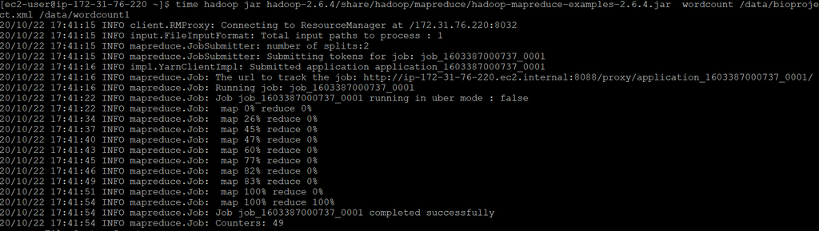

```python
Image(filename='wordcount run.PNG')
```

Time to run wordcount on multi-node cluster:

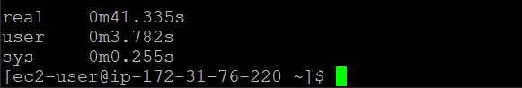

```python
Image(filename='wordcount time.PNG')
```

### Implement Hive

Query in Hive and execution time

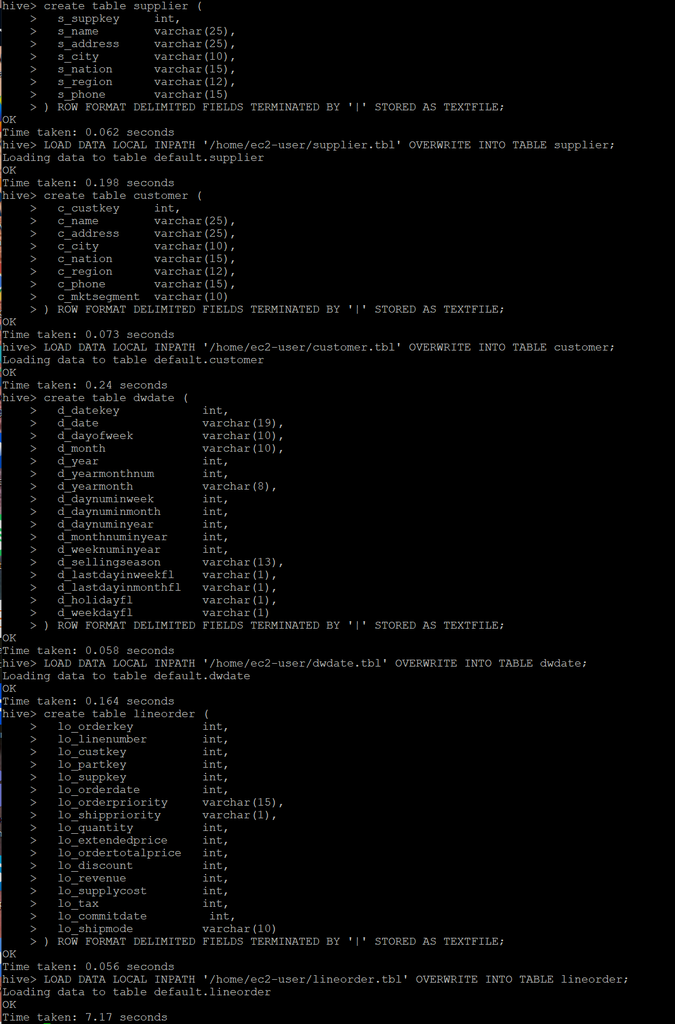

```python
Image(filename='hive load data.PNG')
```

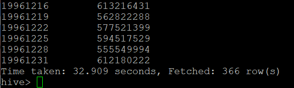

```python
Image(filename='hive query exec time.PNG')
```

Create python file for a Hive transformation

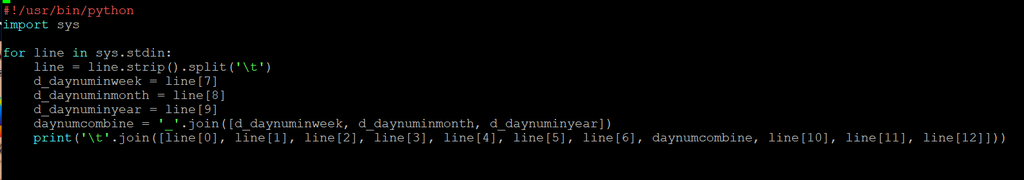

```python
Image(filename='dwdate transform python.PNG')
```

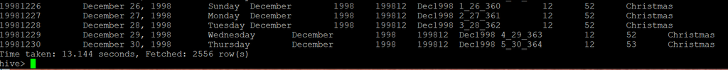

```python
Image(filename='hive transform example output.PNG')
```

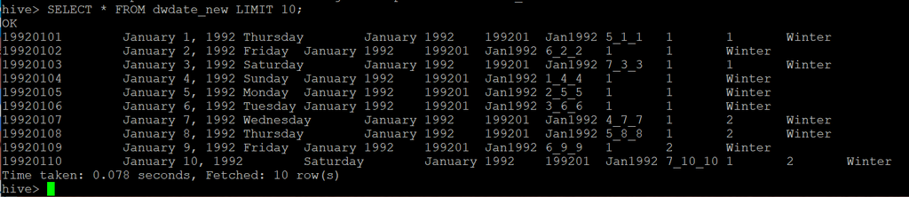

```python
Image(filename='hive transform new table.PNG')
```

### Implement Pig

Create Pig scripts for transformation and query of data

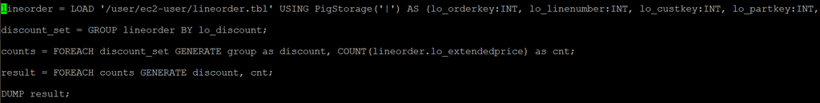

```python
Image(filename='pig query 1 code.PNG')
```

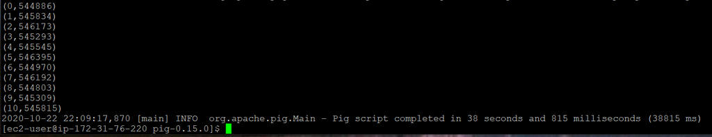

```python
Image(filename='pig query 1 output.PNG')
```

Another Pig script for querying data

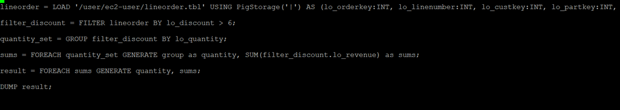

```python
Image(filename='pig query 2 code.PNG')
```

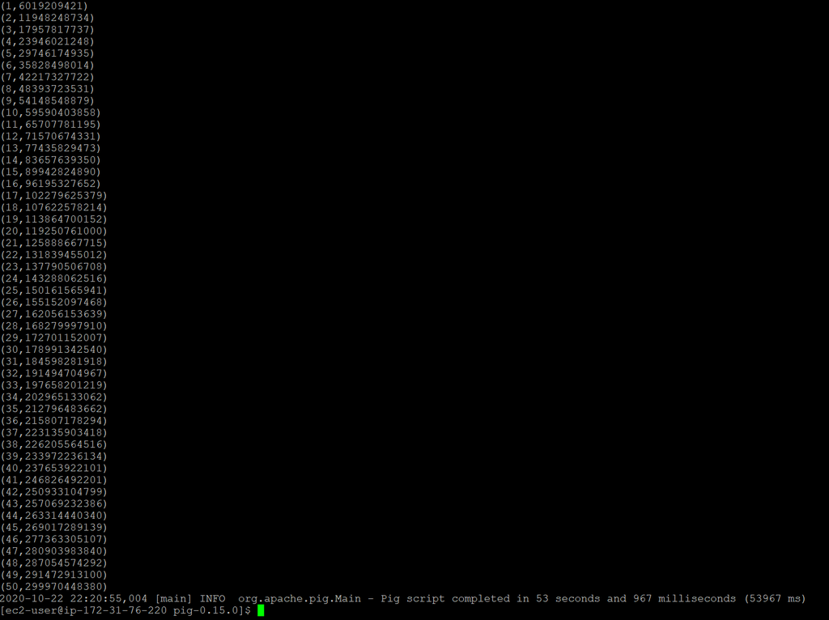

```python
Image(filename='pig query 2 output.PNG')
```

### Hadoop Streaming

Implement a MapReduce pipe for streaming in the HDFS

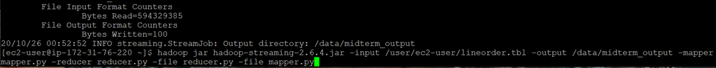

```python
Image(filename='hadoop streaming cmd.PNG')
```

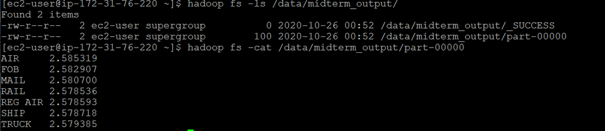

```python
Image(filename='hadoop streaming output.PNG')
```

Mapper python code

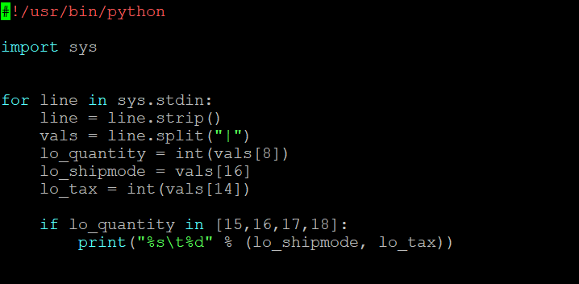

```python
Image(filename='mapper_py.PNG')
```

Reducer python code

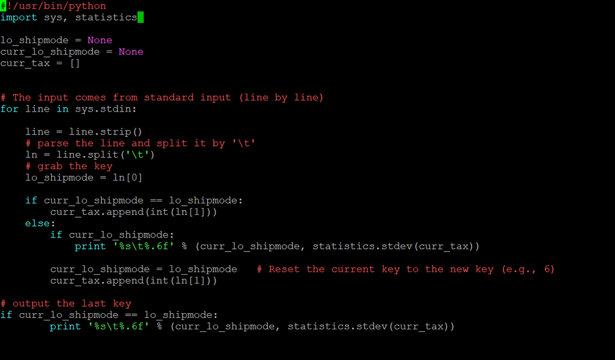

```python
Image(filename='reducer_py.PNG')
```

### Create a two pass MapReduce for join and group by on sample dataset of lineorder items

First pass Python mapper

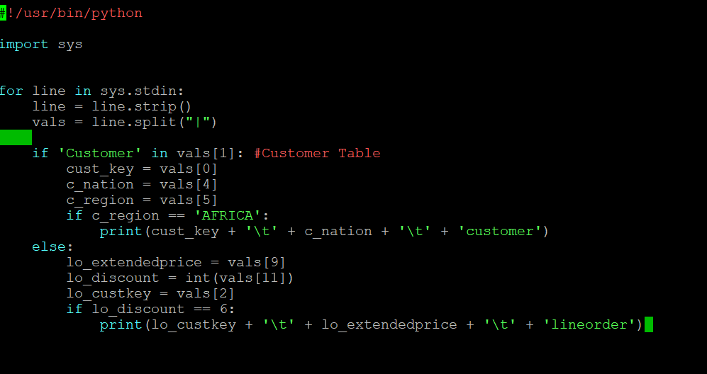

```python
from IPython.display import Image
Image(filename='mapper1.PNG')
```

First pass Python Reducer

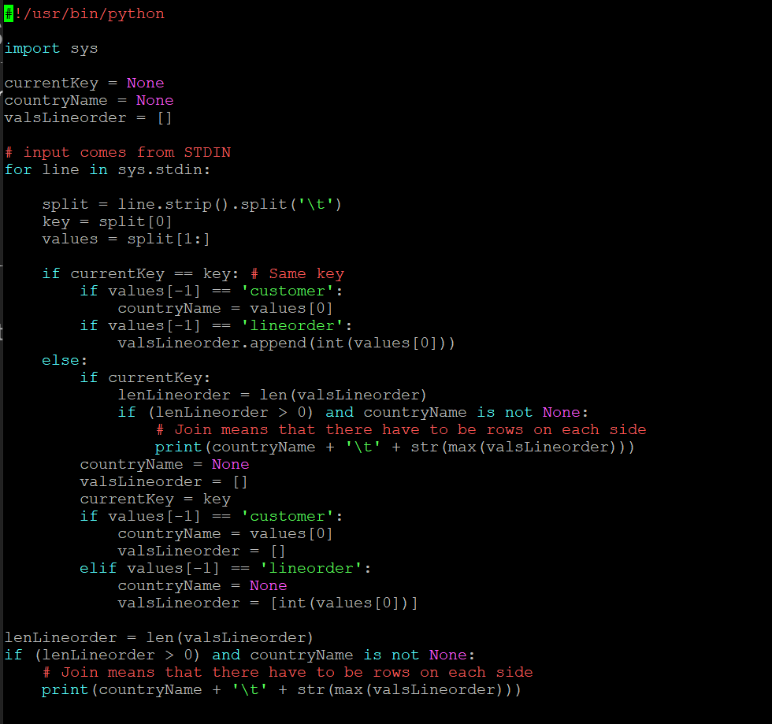

```python
Image(filename='reducer1.PNG')
```

Second pass mapper code

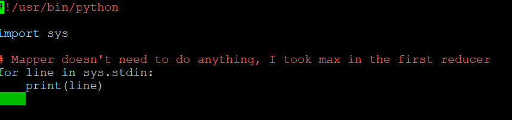

```python
Image(filename='mapper2.PNG')
```

Second Pass reducer code

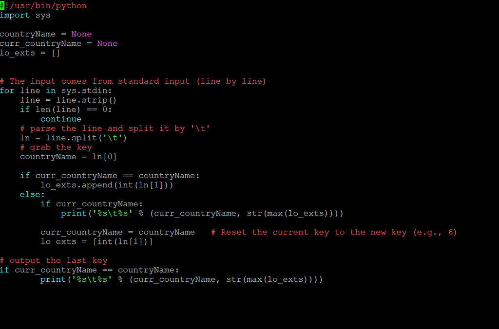

```python
Image(filename='reducer2.PNG')
```

### Hadoop streaming with multiple MapReduce

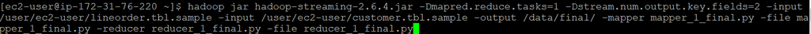

```python
Image(filename='hadoop streaming cmd1.PNG')
```

Second command

```python
Image(filename='hadoop streaming cmd 2.PNG')
```

[figure not shown]

Hadoop streaming output

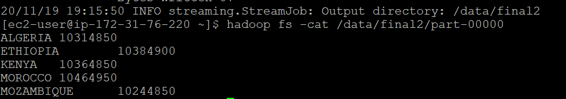

```python
Image(filename='hadoop streaming output final.PNG')
```

#### Implement Pig for similar query of same dataset

Pig code

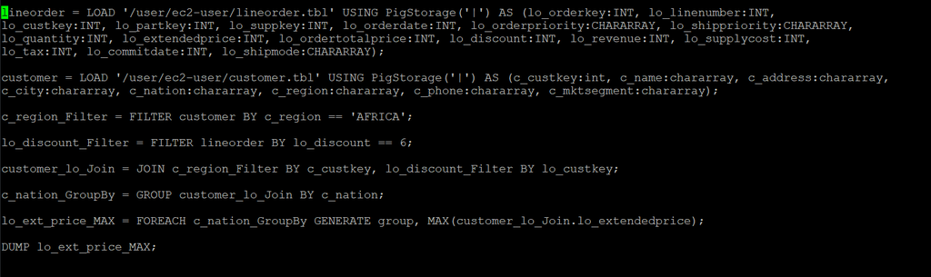

```python
Image(filename='pig code.PNG')
```

Pig output

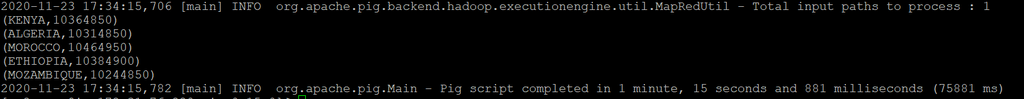

```python
Image(filename='pig output.PNG')
```

### Implement Clustering in Hadoop streaming

Code for generating random numeric file

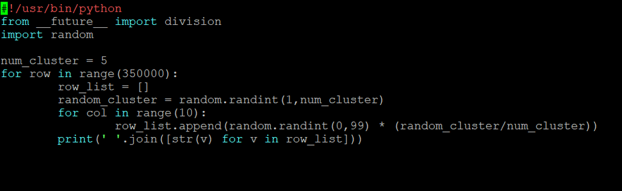

```python
Image(filename='random numerical file code.PNG')
```

Example output of random numeric file

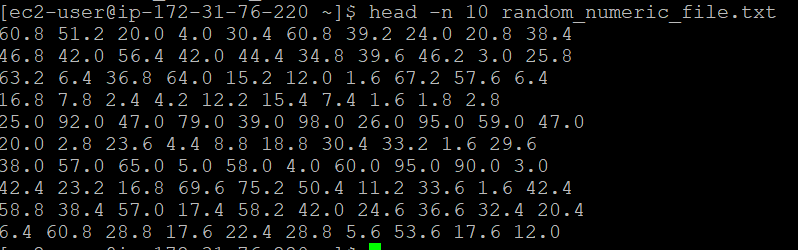

```python
Image(filename='random file head 10.PNG')
```

Randomly selected cluster center file

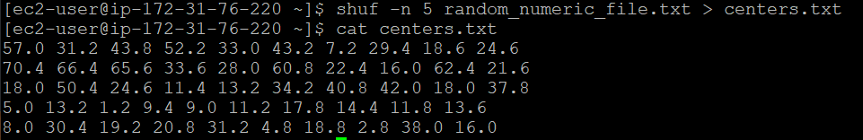

```python
Image(filename='clustering random centers.PNG')
```

Mapper code for generating cluster key, cluster values output  
Each subsequent mapper substitutes the centers[i].txt file name

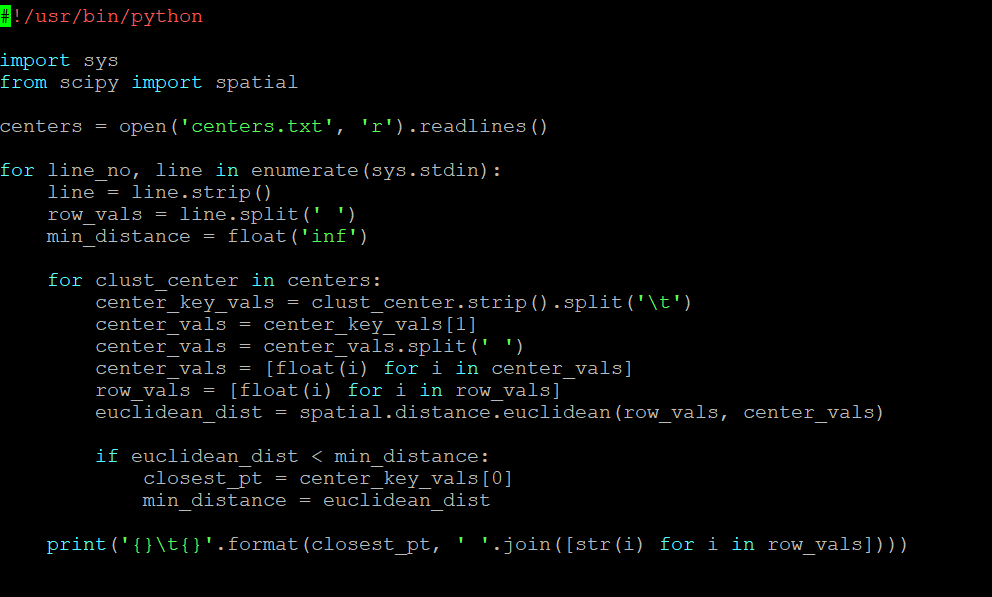

```python
Image(filename='cluster mapper code.PNG')
```

Reducer code for generating new clusters with cluster values

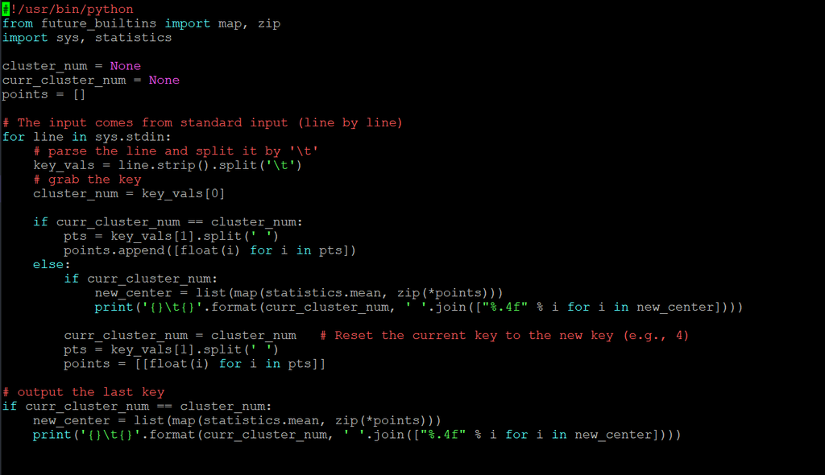

```python
Image(filename='cluster reducer code.PNG')
```

Map reduce first pass command

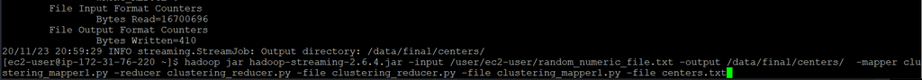

```python
Image(filename='cluster MR iter 1 cmd.PNG')
```

```python
Image(filename='clustering new centers file.PNG')
```

[output not shown]

Map reduce second pass command

```python
Image(filename='cluster MR iter 2 cmd.PNG')
```

[figure not shown]

Map reduce third pass command

```python
Image(filename='cluster MR iter 3 cmd.PNG')
```

[figure not shown]

Map reduce fourth pass command

```python
Image(filename='cluster MR iter 4 cmd.PNG')
```

[figure not shown]

Output of all cluster files

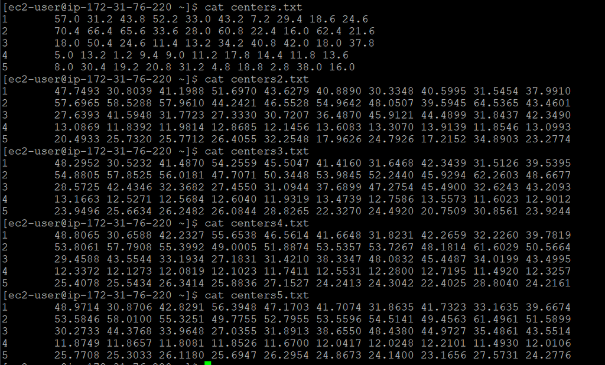

```python
Image(filename='cluster centers files.PNG')
```